# Team 7: Spotify Songs Analysis

Team Members: Sarva Praneeth, Lakshmi Sashrika Pathuri, Aravinda Vijayaram Kumar

# **Introduction**

In the expansive realm of music streaming services, delving into the characteristics of songs can offer valuable insights into both user preferences and genre-specific trends. Amid the vast catalog of tracks accessible on platforms like Spotify, the ability to uncover patterns and connections between diverse audio attributes holds the potential to predict song popularity, curate individualized playlists, and elevate the overall user experience.

This analysis seeks to embark on a journey through the multifaceted landscape of audio features within songs spanning various genres. By examining the distributions of these attributes, uncovering correlations between them, and comprehending their influence on listeners’ choices, we aim to unveil a deeper understanding of how music captivates and resonates with audiences. Through this exploration, we can unlock the secrets that lie within the harmonies, rhythms, and melodies that define our musical world.

# **Dataset**

The real-time dataset under analysis encompasses a comprehensive collection of 42,305 rows, merging information from Spotify’s vast music library. The dataset presents a rich assortment of information, combining various audio features and metadata related to diverse musical tracks, offering a nuanced perspective on the intricate characteristics of contemporary music.

The dataset comprises an array of audio features, including danceability, energy, key, loudness, mode, speechiness, acousticness, instrumentalness, liveness, valence, tempo, and time signature. These features provide valuable insights into the nuanced musical compositions and inherent attributes of each track, enabling a deeper understanding of the multifaceted nature of musical expression and creativity.

Additionally, the dataset incorporates a range of unique identifiers, such as type, id, URI, track_href, and analysis_url, facilitating seamless linkage and retrieval of supplementary information associated with each track. This interconnected system offers an expansive view of the diverse musical landscape, highlighting the interconnected nature of contemporary music production and distribution.

Furthermore, the dataset includes critical information on the duration of each track, meticulously measured in milliseconds, and encompasses genre classifications, specific song names, and titles of individual tracks. This comprehensive dataset serves as a valuable resource for conducting in-depth analyses and uncovering intricate patterns and trends within the dynamic realm of music composition and production.

**Key Columns**:

*Danceability*: Signifies the track’s suitability for dancing, incorporating a blend of musical elements to gauge its rhythmic and dance-friendly nature.

*Energy*: Represents the song’s intensity and activity level, encapsulating features such as tempo, volume, and rhythmic strength to define the overall dynamism and liveliness of the music.

*Key*: Reflects the musical key of the track, determining the pitch and tonality of the music and contributing to the overall melodic structure and tonal composition. Loudness: Indicates the overall volume or amplitude of the song, measured in decibels (dB), offering insights into the track’s auditory presence and sonic impact.

*Mode*: Represents the modality (major or minor) of a track, delineating the type of scale used in the track’s melodic construction and serving as a foundational element in defining the music’s emotional tone and tonal texture.

*Speechiness*: Indicates the presence of spoken words in the song, helping to distinguish between instrumental and vocal-centric compositions.

*Acousticnes*s: Represents the presence of acoustic elements in the song, with high values suggesting a stronger presence of acoustic sounds.

*Instrumentalness*: Reflects the probability of a track being instrumental, with higher values indicating a higher likelihood of the absence of vocals.

*Liveness*: Indicates the likelihood of a track being recorded live, highlighting the presence of an audience or live recording ambiance.

*Valence*: Represents the overall mood and emotional character of a track, typically denoting the positivity or happiness conveyed by the music.

*Tempo*: Indicates the speed or pace of a track, typically measured in beats per minute (BPM), defining the overall rhythm and pacing of the music.

*Duration_ms*: Represents the duration of the track in milliseconds, providing insights into the length and temporal structure of the music.

*Genre*: Indicates the genre or category to which the song belongs, defining its stylistic and thematic classification within the broader spectrum of music.

*Song_name*: Refers to the name or title of the individual song, serving as a distinctive identifier for each musical composition.

*Title*: Represents the title of the track or the name of the musical composition, providing a unique identifier for cataloging and organizational purposes.

*Time_Signature*: Indicates the notational convention specifying the number of beats in each bar or measure, providing insights into the rhythmic structure and temporal organization of the music.

These key columns collectively contribute to a comprehensive understanding of the musical attributes, thematic characteristics, and genre-specific classifications within the Spotify dataset.

There are certain limitations as well in the dataset.The dataset from Spotify provides valuable insights into music characteristics and genre trends, yet it comes with certain limitations that warrant attention. One primary concern revolves around potential biases in the sampled data, which might not fully represent the rich diversity of musical genres and styles. Moreover, the dataset’s static nature could restrict a comprehensive understanding of dynamic shifts in music trends over time. Additionally, the absence of detailed metadata and potential data quality issues, such as missing or inaccurate values, pose challenges to the reliability and robustness of any analytical inferences drawn from the dataset. It is imperative to acknowledge these limitations to ensure a balanced and nuanced interpretation of the dataset’s findings within the broader context of music analysis and industry insights.

Source of dataset: This research project’s dataset (Dataset of songs in Spotify)was obtained via Kaggle, a recognized site for sharing and accessing datasets.**[1]**

# **Exploratory Data Analysis**

Exploratory Data Analysis(EDA) refers to the critical process of performing initial investigations on data so as to discover patterns,to spot anomalies,to test hypothesis and to check assumptions with the help of summary statistics and graphical representations.**[2]**

The main purpose of EDA is to help look at data before making any assumptions. It can help identify obvious errors, as well as better understand patterns within the data, detect outliers or anomalous events, find interesting relations among the variables.**[3]**

Now let us perform some EDA on the spotify dataset-

Loading the dataset-

```r
#Loading the dataset
library(readr)
dataset <- read.csv("genres_v2.csv")
print(str(dataset))
```

```
## 'data.frame':    42305 obs. of  22 variables:
##  $ danceability    : num  0.831 0.719 0.85 0.476 0.798 0.721 0.718 0.694 0.774 0.893 ...
##  $ energy          : num  0.814 0.493 0.893 0.781 0.624 0.568 0.668 0.711 0.751 0.907 ...
##  $ key             : int  2 8 5 0 2 0 8 8 1 11 ...
##  $ loudness        : num  -7.36 -7.23 -4.78 -4.71 -7.67 ...
##  $ mode            : int  1 1 1 1 1 1 1 1 1 1 ...
##  $ speechiness     : num  0.42 0.0794 0.0623 0.103 0.293 0.414 0.137 0.221 0.198 0.367 ...
##  $ acousticness    : num  0.0598 0.401 0.0138 0.0237 0.217 0.0452 0.0254 0.0397 0.0614 0.152 ...
##  $ instrumentalness: num  1.34e-02 0.00 4.14e-06 0.00 0.00 2.12e-01 7.80e-03 0.00 0.00 3.11e-02 ...
##  $ liveness        : num  0.0556 0.118 0.372 0.114 0.166 0.128 0.124 0.112 0.0728 0.558 ...
##  $ valence         : num  0.389 0.124 0.0391 0.175 0.591 0.109 0.038 0.283 0.189 0.302 ...
##  $ tempo           : num  157 115 218 187 148 ...
##  $ type            : chr  "audio_features" "audio_features" "audio_features" "audio_features" ...
##  $ id              : chr  "2Vc6NJ9PW9gD9q343XFRKx" "7pgJBLVz5VmnL7uGHmRj6p" "0vSWgAlfpye0WCGeNmuNhy" "0VSXnJqQkwuH2ei1nOQ1nu" ...
##  $ uri             : chr  "spotify:track:2Vc6NJ9PW9gD9q343XFRKx" "spotify:track:7pgJBLVz5VmnL7uGHmRj6p" "spotify:track:0vSWgAlfpye0WCGeNmuNhy" "spotify:track:0VSXnJqQkwuH2ei1nOQ1nu" ...
##  $ track_href      : chr  "https://api.spotify.com/v1/tracks/2Vc6NJ9PW9gD9q343XFRKx" "https://api.spotify.com/v1/tracks/7pgJBLVz5VmnL7uGHmRj6p" "https://api.spotify.com/v1/tracks/0vSWgAlfpye0WCGeNmuNhy" "https://api.spotify.com/v1/tracks/0VSXnJqQkwuH2ei1nOQ1nu" ...
##  $ analysis_url    : chr  "https://api.spotify.com/v1/audio-analysis/2Vc6NJ9PW9gD9q343XFRKx" "https://api.spotify.com/v1/audio-analysis/7pgJBLVz5VmnL7uGHmRj6p" "https://api.spotify.com/v1/audio-analysis/0vSWgAlfpye0WCGeNmuNhy" "https://api.spotify.com/v1/audio-analysis/0VSXnJqQkwuH2ei1nOQ1nu" ...
##  $ duration_ms     : int  124539 224427 98821 123661 123298 112511 77584 127524 140326 121979 ...
##  $ time_signature  : int  4 4 4 3 4 4 4 3 4 4 ...
##  $ genre           : chr  "Dark Trap" "Dark Trap" "Dark Trap" "Dark Trap" ...
##  $ song_name       : chr  "Mercury: Retrograde" "Pathology" "Symbiote" "ProductOfDrugs (Prod. The Virus and Antidote)" ...
##  $ Unnamed..0      : num  NA NA NA NA NA NA NA NA NA NA ...
##  $ title           : chr  "" "" "" "" ...
## NULL
```

Displaying dimensions of the dataset

```r
# Dimensions of the dataset
dim(dataset)
```

```
## [1] 42305    22
```

Obtaining and displaying the summary of the dataset

```r
# Summary of the dataset
summary(dataset)
```

```
##   danceability        energy              key           loudness
##  Min.   :0.0651   Min.   :0.000243   Min.   : 0.00   Min.   :-33.357
##  1st Qu.:0.5240   1st Qu.:0.632000   1st Qu.: 1.00   1st Qu.: -8.161
##  Median :0.6460   Median :0.803000   Median : 6.00   Median : -6.234
##  Mean   :0.6394   Mean   :0.762516   Mean   : 5.37   Mean   : -6.465
##  3rd Qu.:0.7660   3rd Qu.:0.923000   3rd Qu.: 9.00   3rd Qu.: -4.513
##  Max.   :0.9880   Max.   :1.000000   Max.   :11.00   Max.   :  3.148
##
##       mode         speechiness      acousticness       instrumentalness
##  Min.   :0.0000   Min.   :0.0227   Min.   :0.0000011   Min.   :0.00000
##  1st Qu.:0.0000   1st Qu.:0.0491   1st Qu.:0.0017300   1st Qu.:0.00000
##  Median :1.0000   Median :0.0755   Median :0.0164000   Median :0.00594
##  Mean   :0.5495   Mean   :0.1366   Mean   :0.0961605   Mean   :0.28305
##  3rd Qu.:1.0000   3rd Qu.:0.1930   3rd Qu.:0.1070000   3rd Qu.:0.72200
##  Max.   :1.0000   Max.   :0.9460   Max.   :0.9880000   Max.   :0.98900
##
##     liveness         valence           tempo            type
##  Min.   :0.0107   Min.   :0.0187   Min.   : 57.97   Length:42305
##  1st Qu.:0.0996   1st Qu.:0.1610   1st Qu.:129.93   Class :character
##  Median :0.1350   Median :0.3220   Median :144.97   Mode  :character
##  Mean   :0.2141   Mean   :0.3571   Mean   :147.47
##  3rd Qu.:0.2940   3rd Qu.:0.5220   3rd Qu.:161.46
##  Max.   :0.9880   Max.   :0.9880   Max.   :220.29
##
##       id                uri             track_href        analysis_url
##  Length:42305       Length:42305       Length:42305       Length:42305
##  Class :character   Class :character   Class :character   Class :character
##  Mode  :character   Mode  :character   Mode  :character   Mode  :character
##
##
##
##
##   duration_ms     time_signature     genre            song_name
##  Min.   : 25600   Min.   :1.000   Length:42305       Length:42305
##  1st Qu.:179840   1st Qu.:4.000   Class :character   Class :character
##  Median :224760   Median :4.000   Mode  :character   Mode  :character
##  Mean   :250866   Mean   :3.973
##  3rd Qu.:301133   3rd Qu.:4.000
##  Max.   :913052   Max.   :5.000
##
##    Unnamed..0       title
##  Min.   :    0   Length:42305
##  1st Qu.: 5256   Class :character
##  Median :10480   Mode  :character
##  Mean   :10484
##  3rd Qu.:15709
##  Max.   :20999
##  NA's   :21525
```

These are the coloumns-

```r
column_names <- colnames(dataset)
print(column_names)
```

```
##  [1] "danceability"     "energy"           "key"              "loudness"
##  [5] "mode"             "speechiness"      "acousticness"     "instrumentalness"
##  [9] "liveness"         "valence"          "tempo"            "type"
## [13] "id"               "uri"              "track_href"       "analysis_url"
## [17] "duration_ms"      "time_signature"   "genre"            "song_name"
## [21] "Unnamed..0"       "title"
```

Dropping `Unnnamed..0` column-

```r
dataset_na <- subset(dataset,select = -Unnamed..0)
print(colnames(dataset_na))
```

```
##  [1] "danceability"     "energy"           "key"              "loudness"
##  [5] "mode"             "speechiness"      "acousticness"     "instrumentalness"
##  [9] "liveness"         "valence"          "tempo"            "type"
## [13] "id"               "uri"              "track_href"       "analysis_url"
## [17] "duration_ms"      "time_signature"   "genre"            "song_name"
## [21] "title"
```

Checking if we have any NA values in any of the coloumns-

```r
null_counts <- colSums(is.na(dataset_na))
print(null_counts)
```

```
##     danceability           energy              key         loudness
##                0                0                0                0
##             mode      speechiness     acousticness instrumentalness
##                0                0                0                0
##         liveness          valence            tempo             type
##                0                0                0                0
##               id              uri       track_href     analysis_url
##                0                0                0                0
##      duration_ms   time_signature            genre        song_name
##                0                0                0                0
##            title
##                0
```

Filling of there any blank values with NA values-

```r
dataset_na[dataset_na == " "] <- NA
null_counts1 <- colSums(is.na(dataset_na))
print(null_counts1)
```

```
##     danceability           energy              key         loudness
##                0                0                0                0
##             mode      speechiness     acousticness instrumentalness
##                0                0                0                0
##         liveness          valence            tempo             type
##                0                0                0                0
##               id              uri       track_href     analysis_url
##                0                0                0                0
##      duration_ms   time_signature            genre        song_name
##                0                0                0                0
##            title
##                0
```

In the initial stage of data preparation, we conducted a thorough check to identify any missing values in the dataset across various columns. Following this, we proceeded to address any empty or blank entries by appropriately filling them with NA values for further clarity and consistency. This preprocessing step enabled us to ensure the integrity and completeness of the dataset, providing a reliable foundation for subsequent data analysis and visualization. With these essential data handling procedures completed, we were well-equipped to proceed with the visualization and exploration of the dataset to glean valuable insights and patterns.

### **Visulaization of Data**

Data visualization is an important component of Exploratory Data Analysis (EDA) because it allows a data analyst to “look at” their data and get to know the variables and relationships between them.**[4]**

Let us first visualize individual quantitative variables-

**Univariate analysis** focuses on a single variable at a time. Box plots (or violin plots) and histograms are common choices for visually summarizing a quantitative variable. These plots are useful because they simultaneously communicate information about minimum and maximum values, central location, and spread. Histograms can additionally illuminate patterns that can impact an analysis.**[4]**

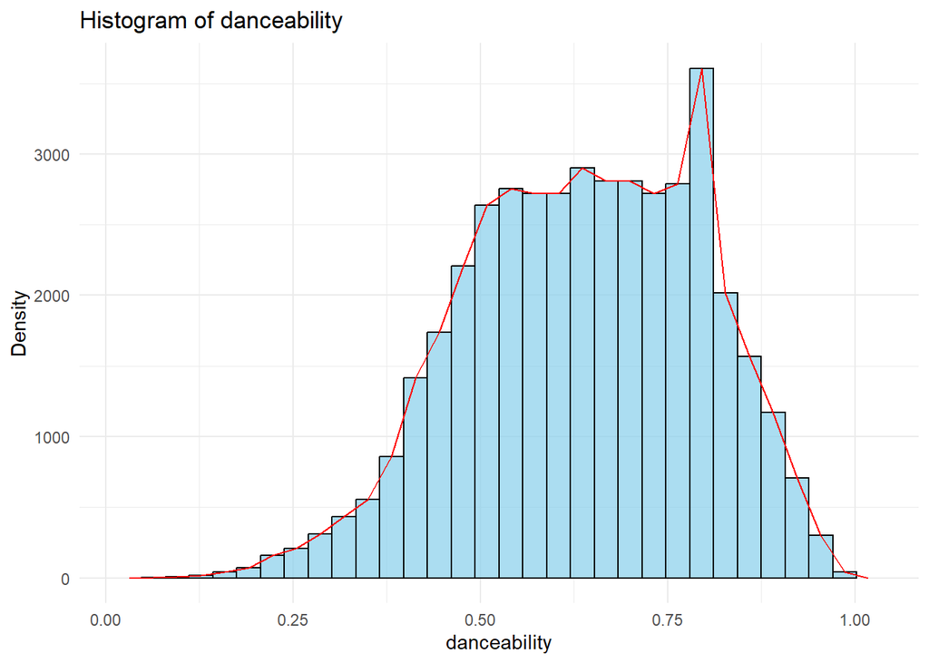

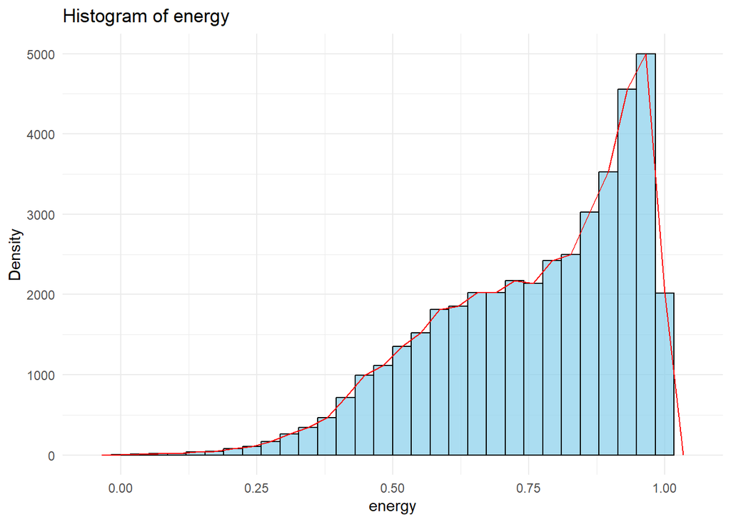

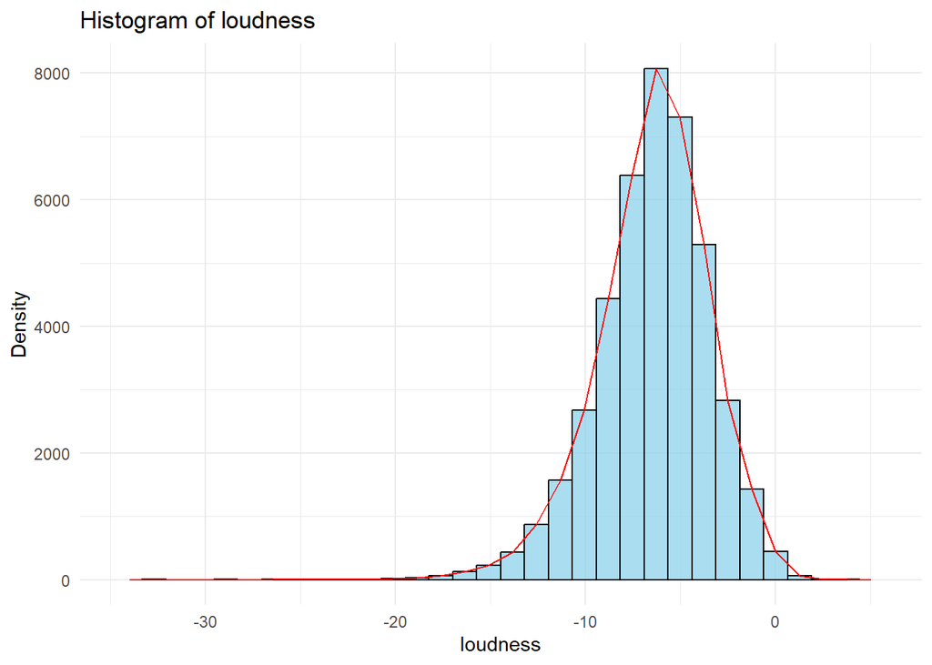

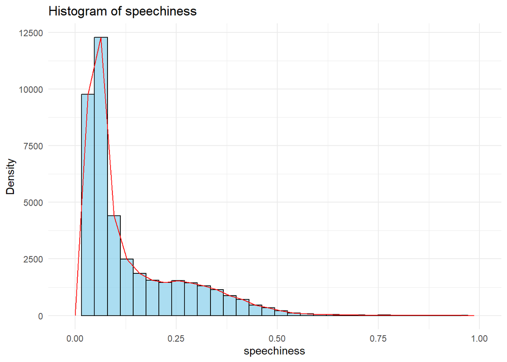

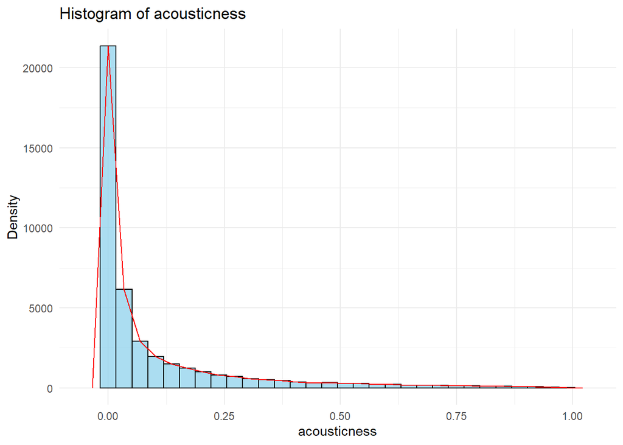

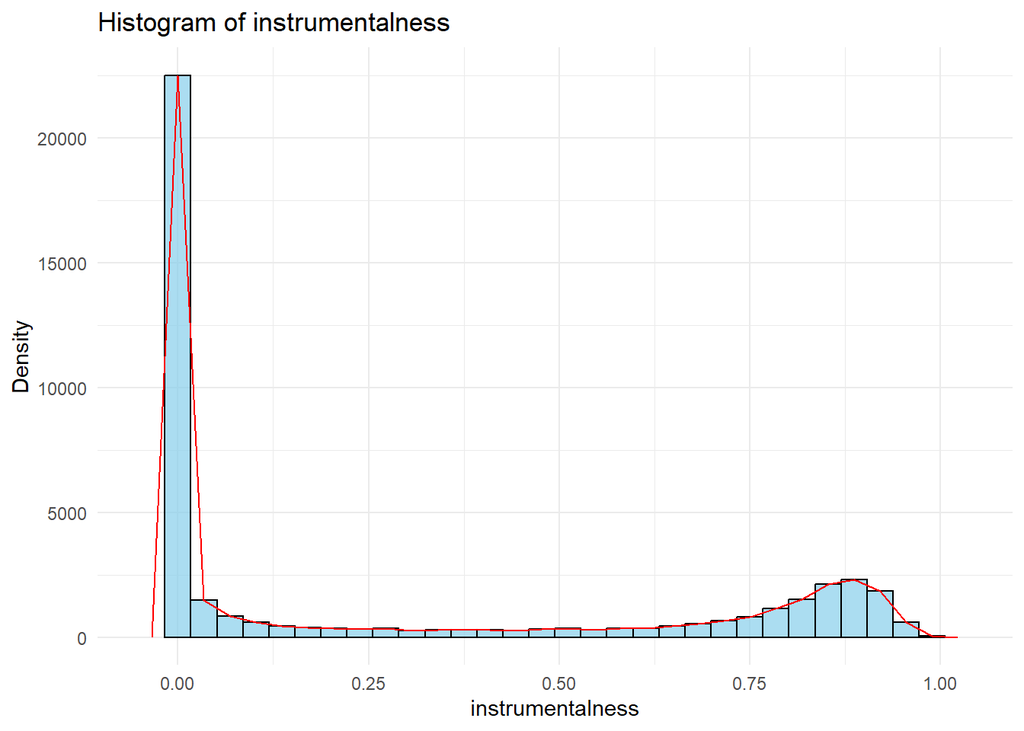

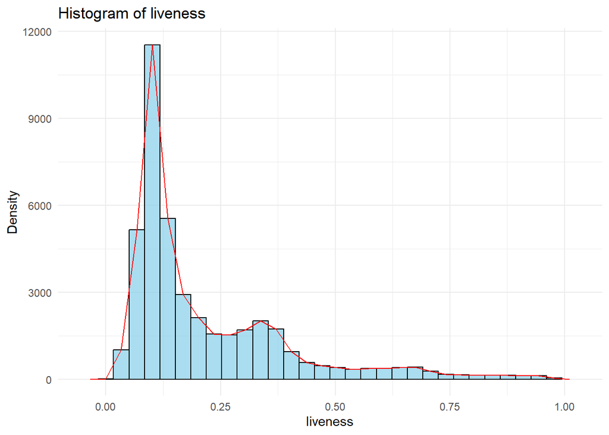

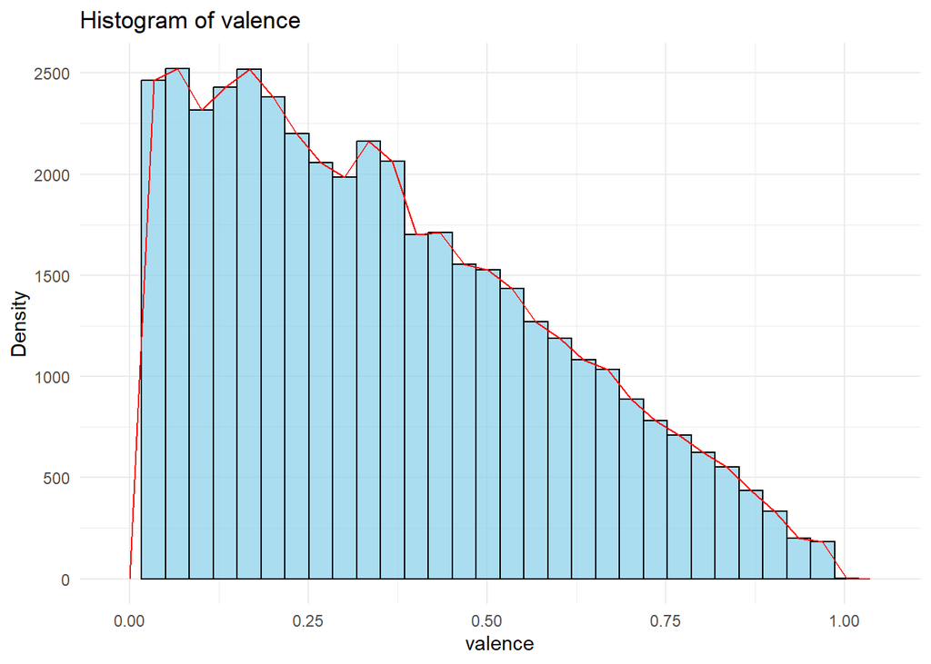

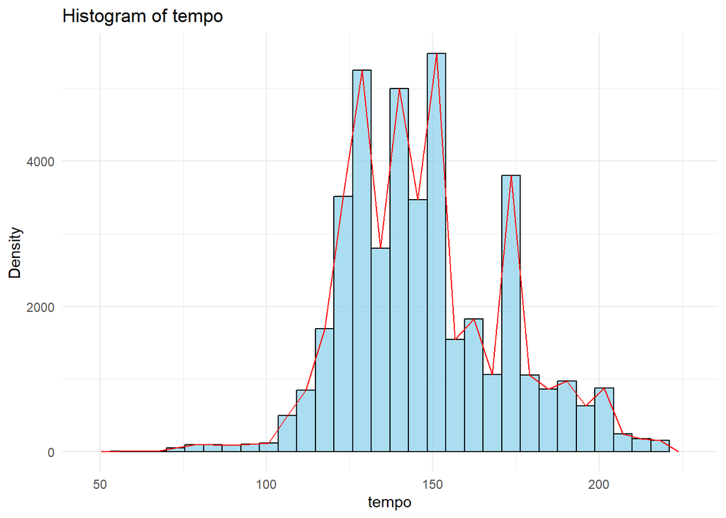

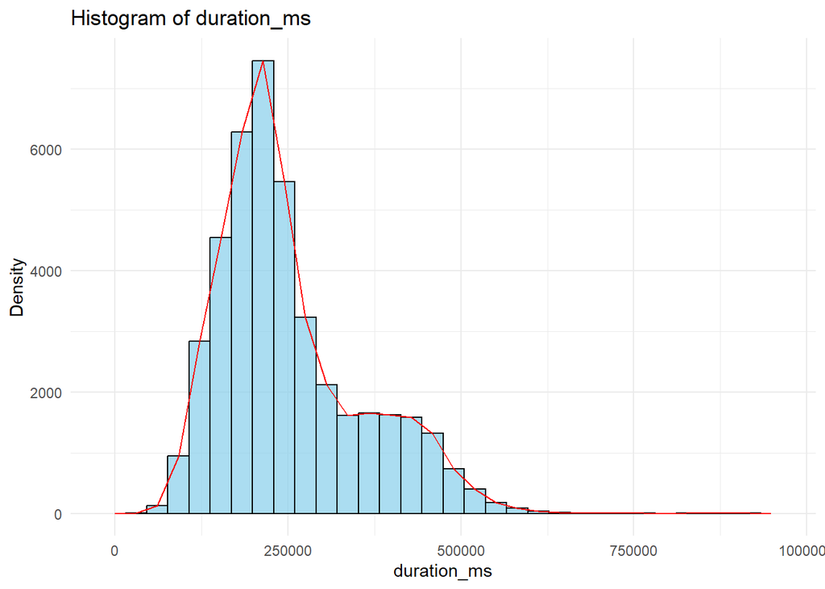

```r
# Visualisation of data
library(ggplot2)
library(dplyr)
library(tidyr)


# Plotting histograms for continuous variables
continuous_vars <- c("danceability", "energy", "loudness", "speechiness",
                     "acousticness", "instrumentalness", "liveness",
                     "valence", "tempo", "duration_ms")

par(mfrow=c(5,2), mar=c(4,4,2,1))
for(var in continuous_vars) {
  p <- ggplot(dataset_na, aes_string(x=var)) +
    geom_histogram(aes(y=..count..), bins=30, fill="skyblue",col="black", alpha=0.7) +
    geom_freqpoly(color="red") +
    labs(title=paste('Histogram of', var),
         x=var, y='Density') +
    theme_minimal()
  print(p)
}
```

We can summarize the following points from our visualized graphs:

*Danceability:*- The data shows that a considerable portion of the songs in the dataset are quite dance-friendly, as seen in the peak between 0.7 and 0.8 danceability range. These tracks tend to have strong beats and rhythms that make them ideal for dancing. Conversely, there are also songs with lower danceability values, indicating a category of tracks less suitable for dancing, possibly due to slower tempos or less pronounced rhythms.

*Loudness:*- The tracks primarily fall within the -10 to -5 decibels loudness range, indicating a standardized loudness in the dataset. Many tracks are likely mastered to maintain a consistent loudness for a balanced listening experience. This normalization is a common practice during production to ensure a certain loudness level, enhancing overall listening quality. These values align with what’s typical in popular music, providing a uniform auditory experience for listeners.

*Speechiness:*- Low speechiness values dominate, indicating that most tracks emphasize instrumental content over spoken words. The focus in these tracks is primarily on musical composition and arrangement, with less emphasis on spoken expressions. However, highly speechy tracks in the dataset include spoken word or rap elements, prioritizing lyrical storytelling or spoken narratives. This adds diversity to musical styles and thematic content in the dataset. Values between 0.33 and 0.66 may combine music and speech, such as rap music, while values below 0.33 primarily represent music without speech elements.

*Instrumentalness:*- The high frequency of low instrumentalness values shows that vocals are common in most tracks. These vocal elements, like singing or spoken words, enhance the musical storytelling. Yet, some tracks have high instrumentalness values, indicating purely instrumental compositions. These tracks rely solely on musical instruments, emphasizing melody, arrangement, and the musical experience without vocals.

*Liveness:*- The prevalence of low liveness values suggests that most tracks are studio recordings, likely not captured in live performance settings. On the flip side, high liveness values in some tracks indicate live performance recordings, possibly from concerts. This diversity in liveness values showcases various recording styles and performance contexts within the dataset.

*Duration:*- The bulk of tracks fall within the 1.6 to 6.6-minute range, reflecting typical song lengths in popular music. This range aligns with the standard duration observed in various music genres. However, a few exceptionally long or very short tracks may stand out as unusual outliers, possibly showcasing experimental or niche musical styles.

Now let us visualize and analyze the categorical variables- For categorical variables, we can use a bar plot (instead of a histogram) to quickly visualize the frequency (or proportion) of values in each category.**[4]**

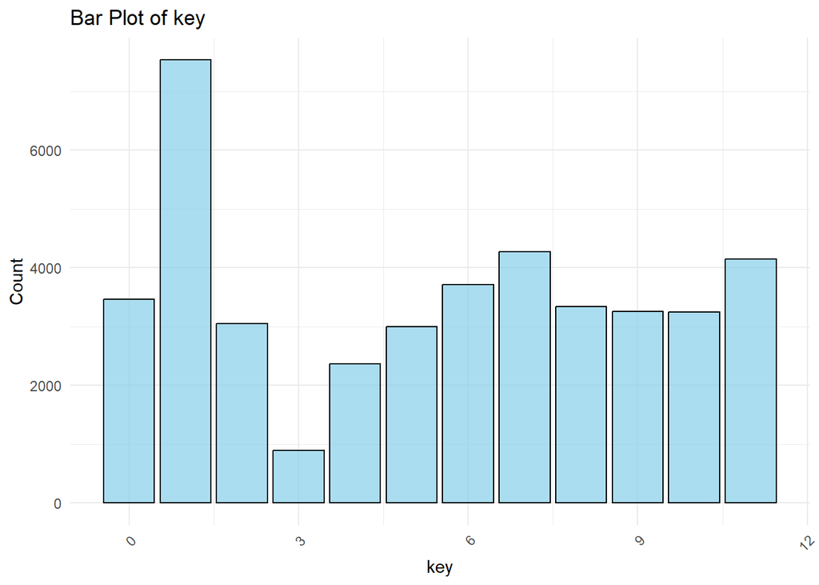

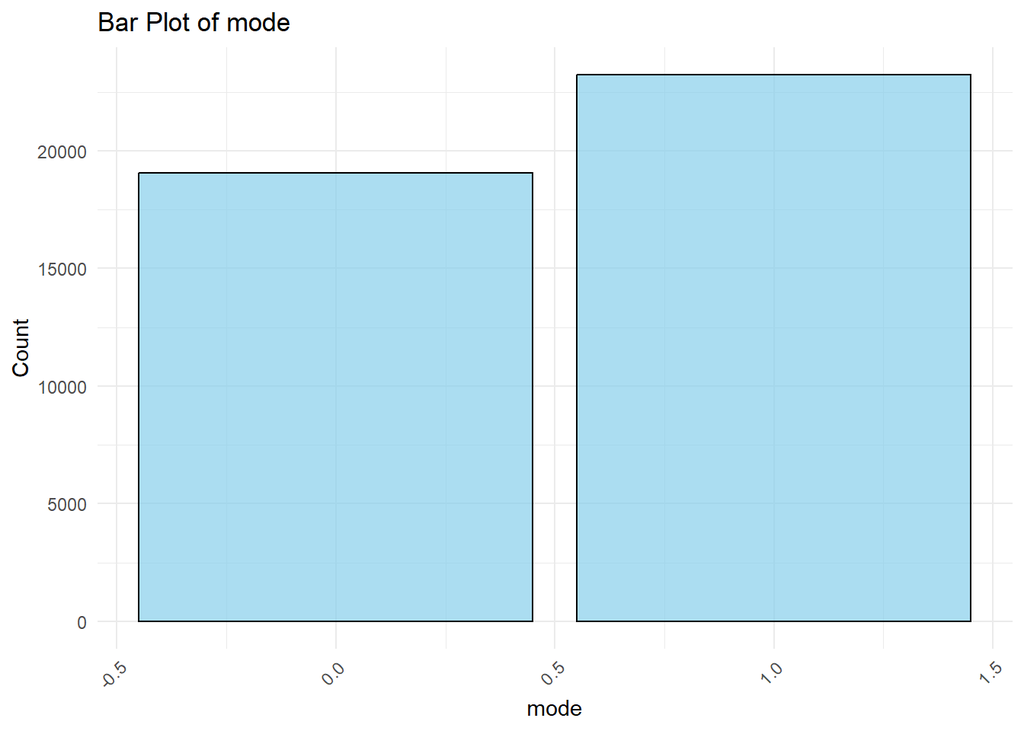

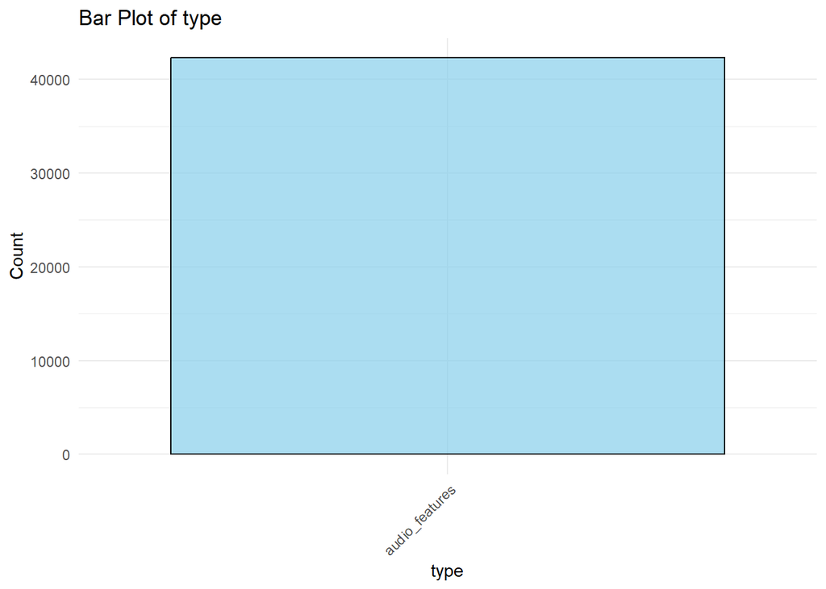

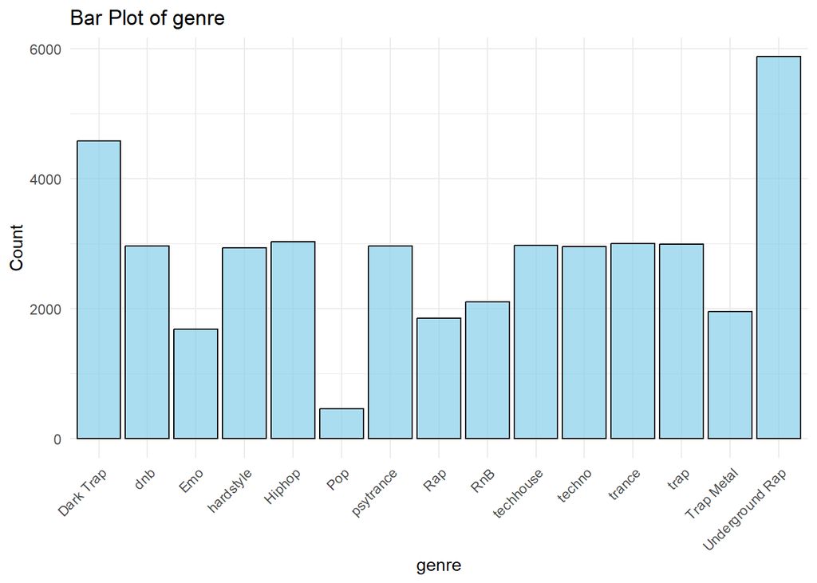

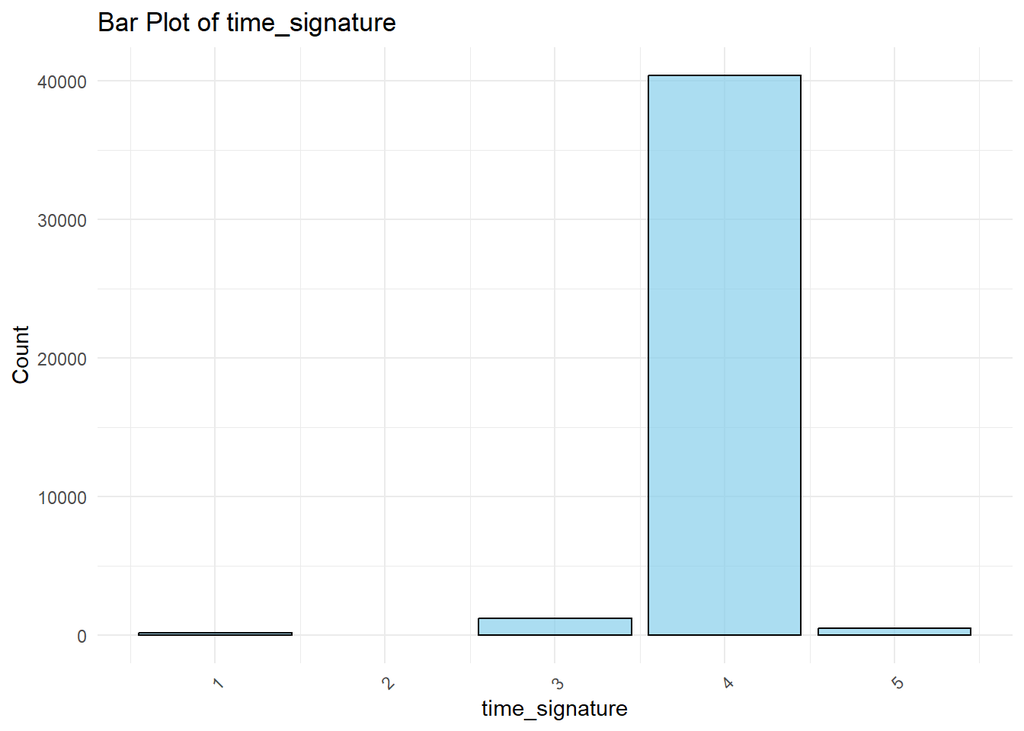

```r
# Bar plots for categorical variables
categorical_vars <- c("key", "mode", "type", "genre", "time_signature")

for(var in categorical_vars) {
  p <- ggplot(dataset_na, aes_string(x=var)) +
    geom_bar(aes(y=after_stat(count)), fill="skyblue",col="black", alpha=0.7) +
    labs(title=paste('Bar Plot of', var),
         x=var, y='Count') +
    theme_minimal() +
    theme(axis.text.x = element_text(angle=45, hjust=1))
  print(p)
}
```

We can summarize the following observations from the plots:

*Mode:*-In terms of the mode distribution, the dataset predominantly comprises tracks in mode “1,” representing the major scale. This prevalence of tracks in the major scale underscores the inclination towards a more uplifting and optimistic tonal quality in the compositions. On the other hand, the dataset includes a smaller proportion of tracks in mode “0,” denoting the minor scale, which often contributes to a more introspective and melancholic tonal mood. The presence of both major and minor modes suggests the incorporation of contrasting emotional nuances and tonal textures, contributing to the overall diversity and depth of the musical selections included in the dataset.

*Type:*-All tracks are of the type “audio_features”. This column does not provide any variability.

After obtaining insights through analysis of individual variables, let us now look into the relationship and interdependence between selected groups of 2 variables

**Bivariate analysis** serves as a fundamental tool in data analysis, enabling researchers to investigate the relationship between two variables within a dataset. By examining the interactions and associations between these variables, analysts can uncover valuable insights into how changes in one variable might impact the other. This form of analysis allows for the identification of patterns, trends, and correlations that might exist between the two variables, providing a comprehensive understanding of their interdependence. Through various statistical techniques and visualization methods, researchers can gain a deeper comprehension of the complex relationships and dynamics at play within the dataset, thereby facilitating informed decision-making and the formulation of data-driven conclusions.

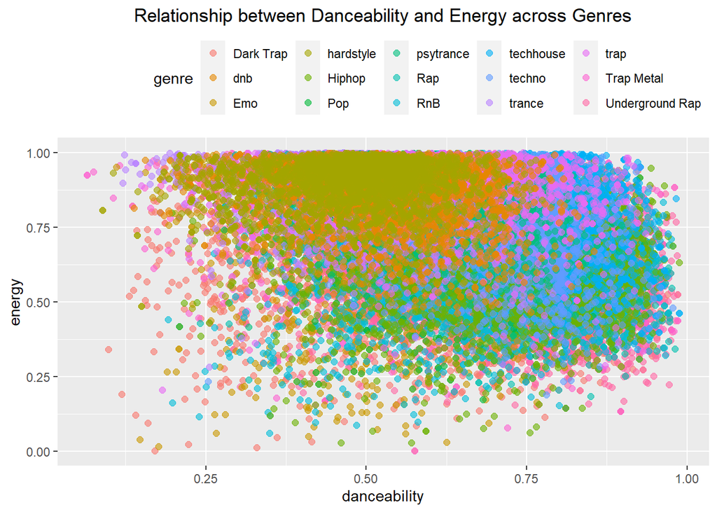

```r
library(ggplot2)

# Danceability vs. Energy
p1 <- ggplot(dataset_na, aes(x=danceability, y=energy, color=genre)) +
  geom_point(alpha=0.6, size=2) +
  theme(legend.position="top",
        legend.justification=c(1,1),
        legend.box.just="right") +
  labs(title='Relationship between Danceability and Energy across Genres') +
  theme(plot.title = element_text(hjust = 0.5))

# Loudness vs. Valence
p2 <- ggplot(dataset_na, aes(x=loudness, y=valence, color=genre)) +
  geom_point(alpha=0.6, size=2) +
  theme_bw() +
  labs(title="Relationship between Loudenss and valence across Genres")

# Acousticness vs. Instrumentalness
p3 <- ggplot(dataset_na, aes(x=acousticness, y=valence, color=genre)) +
  geom_point(alpha=0.6, size=2) +
  theme_bw() +
  labs(title="Relationship between Acousticness and Valence across Genres")

# Ploting all together
library(gridExtra)
print(p1)
```

**Relationship between Danceability and Energy across Genres:**

We can question ourselves like “But doesn’t it mean that if a person is dancing to a song, it’s because the song has higher energy? Why does the correlation matrix indicate the opposite?”

While the perception that high-energy songs often encourage dancing is commonly held, the intricacies of the observed negative correlation between danceability and energy in the dataset warrant a nuanced understanding.Songs with higher energy levels often encourage dancing due to their fast tempos and pronounced beats. However, the observed negative correlation between danceability and energy in the dataset can be attributed to several factors that complicate this relationship. Spotify’s definition of danceability encompasses various musical elements beyond tempo, accounting for the complexity of how different songs may facilitate dancing. Moreover, the concept of energy in music encompasses a broader spectrum, including factors like dynamic range, perceived loudness, and overall complexity, which could influence its correlation with danceability. The diversity of genres represented in the dataset further contributes to this complexity, as different musical styles may prioritize rhythm and beat without necessarily emphasizing high energy levels. While these explanations shed light on the observed negative correlation, a comprehensive analysis involving genre-specific trends and a qualitative evaluation of the tracks could provide a more comprehensive understanding of the intricate interplay between danceability and energy within the context of diverse music genres.

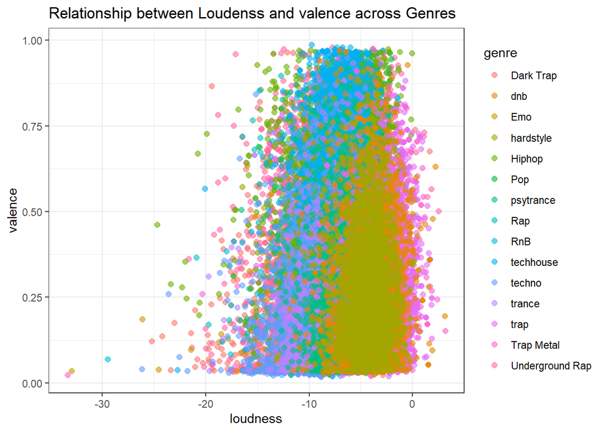

```r
print(p2)
```

**Relationship between Loudness and Valence across Genres:**

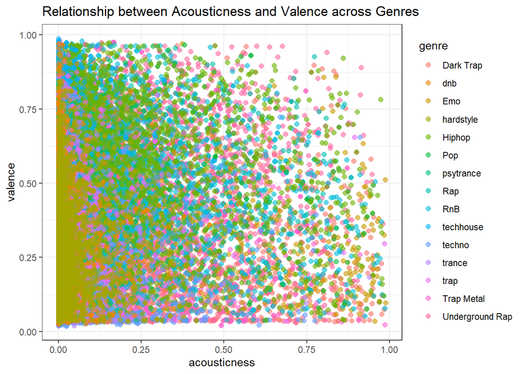

```r
print(p3)
```

**Relationship between Acousticness and Valence across Genres:**

The significance of acousticness and instrumentalness in a song’s attributes is integral to understanding its musical style and production orientation. A lower acousticness value often implies a reduced reliance on traditional acoustic instruments, which is commonly associated with contemporary or electronically produced soundscapes. This trend is frequently observed in modern music genres, such as electronic, pop, and dance music, where the emphasis is placed on synthesized sounds and digital production techniques. On the other hand, higher acousticness values combined with lower instrumentalness levels suggest a strong focus on vocals and lyrical content, with genres like “Ballads” or “Folk” epitomizing this vocal-centric approach. In these genres, the spotlight remains on storytelling and emotive expression through intimate, acoustic-driven musical experiences that resonate deeply with listeners.

Tracks with elevated instrumentalness and diminished acousticness often dominate genres like “Ambient” or “Instrumental Rock,” highlighting the priority given to intricate instrumental arrangements and experimental sonic textures. These genres tend to foster contemplative and immersive musical explorations, utilizing rich instrumental prowess and innovative sound designs to create atmospheric and captivating musical journeys. The deliberate choice to downplay acoustic elements allows these genres to delve into intricate instrumental experimentation, resulting in distinct and introspective listening experiences. Furthermore, while songs with both high acousticness and instrumentalness values are relatively uncommon, genres like “Classical Crossover” challenge this trend by seamlessly fusing classical and contemporary elements. This fusion creates a vibrant and diverse musical landscape, harmoniously blending traditional acoustic instruments with modern production techniques to offer dynamic and engaging musical experiences that resonate with a wide audience.

Overall, these plots provide insights into the relationships between various audio features and how they are distributed across different genres. The clustering of certain genres in specific regions of the plots indicates characteristic sound profiles for these genres, which can be useful for genre classification or recommendation tasks.

Now let us look at a **Correlation plot** to analyze the relationship between the parameters-

Correlations describe the mutual relationship between two variables. They provide the possibility to measure the relation between any kind of quantitative data - may it be continuous, discrete and interval data, yet there are even correlations for ordinal data, although these shall be less relevant for us. Correlations can tell us whether two variables are related, but cannot tell us anything about the causality between the variables.**[5]**

R package corrplot provides a visual exploratory tool on correlation matrix that supports automatic variable reordering to help detect hidden patterns among variables.

corrplot is very easy to use and provides a rich array of plotting options in visualization method, graphic layout, color, legend, text labels, etc. It also provides p-values and confidence intervals to help users determine the statistical significance of the correlations.**[6]**

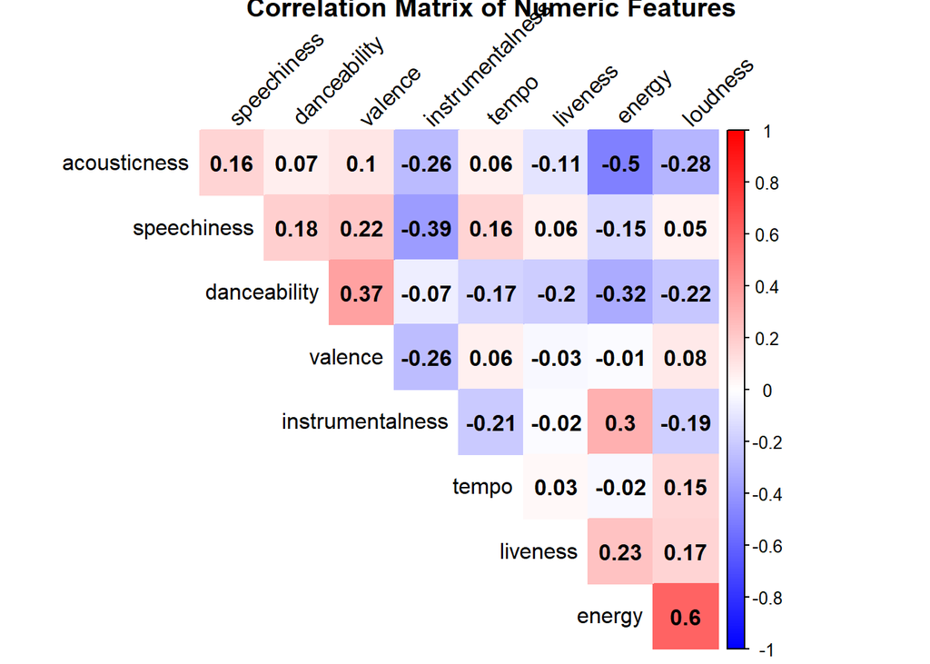

```r
library(corrplot)
columns_to_test <- c('danceability', 'energy', 'loudness', 'speechiness', 'acousticness', 'instrumentalness', 'liveness', 'valence', 'tempo')
correlation_data <- dataset_na[, columns_to_test]
correlation_matrix <- cor(correlation_data, use="complete.obs")


# Plotting the heatmap of the correlation matrix using corrplot
corrplot(correlation_matrix, method="color", col= colorRampPalette(c("blue", "white", "red"))(200),
         type="upper", order="hclust",
         tl.col="black", tl.srt=45,
         addCoef.col = "black", # Add correlation coefficients
         diag=FALSE) # Do not display diagonal

title("Correlation Matrix of Numeric Features", line=3.5)
```

Some Observations from Corrplot are as follows-

*Loudness and Energy*-The strong positive correlation between loudness and energy signifies that songs with higher volumes tend to be more dynamic and vibrant. This relationship highlights the perceptual connection between a song’s loudness and its perceived energy levels, suggesting that louder songs often evoke a sense of heightened excitement or intensity.

*Acousticness and Energy*-The strong negative correlation between acousticness and energy indicates that tracks with acoustic elements tend to have a calmer and more subdued energy profile. Acoustic songs, characterized by their emphasis on natural sounds and organic instrumentation, often evoke a more intimate and mellow ambiance, leading to a lower energy perception.

*Acousticness and Loudness*-The negative correlation between acousticness and loudness points to the tendency for acoustic tracks to be softer and more delicately produced, emphasizing a more intimate and nuanced auditory experience. This link underlines the relationship between acoustic music and its preference for a more restrained and subtle sonic presentation.

*Instrumentalness and Speechiness*-The negative correlation between instrumentalness and speechiness suggests that tracks with a more instrumental focus contain fewer vocal elements. This relationship emphasizes the contrast between instrumental and vocal-centric compositions, highlighting the pivotal role of vocals in conveying lyrical content and storytelling within a song.

*Danceability and Valence*-The positive correlation between danceability and valence signifies that more danceable tracks are often associated with a positive mood or emotional tone. This relationship underscores the connection between the rhythmic elements of a song and its ability to evoke joy, happiness, or a positive emotional response among listeners.

Other Features-Most other features show low correlation values, indicating they don’t linearly depend on each other.

### **Performing normality test on the variables(Kolmogorov-smirnov(K-S) test):**

The Kolmogorov-Smirnov tests conducted on variables, including danceability, energy, and loudness, clearly indicate non-normal distributions. With consistent p-values of 0.0 across all variables and notably high KS statistics, the data significantly deviates from normality. Such findings underscore the importance of non-parametric methods in subsequent analyses of this dataset.

```r
columns_to_test <- c('danceability', 'energy', 'loudness', 'speechiness',
                     'acousticness', 'instrumentalness', 'liveness', 'valence')

# Initializing empty vectors to store results
stats <- numeric(length(columns_to_test))
p_vals <- numeric(length(columns_to_test))

# Performing the K-S test for each column
for (i in 1:length(columns_to_test)) {

  column <- columns_to_test[i]
  data <- na.omit(dataset_na[[column]])
  standardized_data <- (data - mean(data)) / sd(data)

  test_result <- ks.test(standardized_data, "pnorm")

  stats[i] <- test_result$statistic
  p_vals[i] <- test_result$p.value
}
# Creating a data frame to display results
ks_results_df <- data.frame(
  Feature = columns_to_test,
  Statistic = stats,
  P_value = p_vals
)

ks_results_df
```

```
##            Feature  Statistic P_value
## 1     danceability 0.04553836       0
## 2           energy 0.10295940       0
## 3         loudness 0.03995445       0
## 4      speechiness 0.21145362       0
## 5     acousticness 0.28674926       0
## 6 instrumentalness 0.30293277       0
## 7         liveness 0.19269211       0
## 8          valence 0.07835720       0
```

NULL HYPOTHESIS : The data follows a normal distribution.

The p-values for all columns are 0.000, which means we can reject the null hypothesis that the data follows a normal distribution for all the columns tested and The KS statistic values are quite high for most of the variables, further confirming the deviation from normality. This indicates that the selected columns do not follow a normal distribution

NOTE : We cannot completely rely on the K-S Test as our dataset has many observations and usually these tests provide inaccurate information when theyre fed large data. So We will be relying on the visual plots to decide if the data is normal or not. So we are gonna rely on QQ plots to check about normality of data

### **QQ plots:**

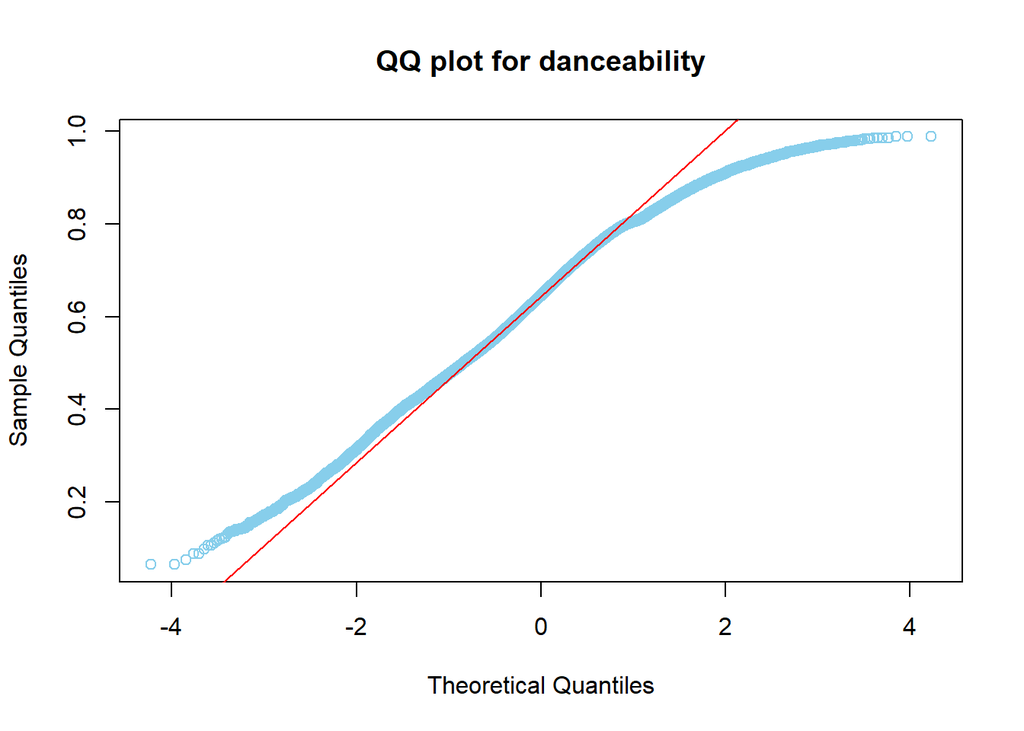

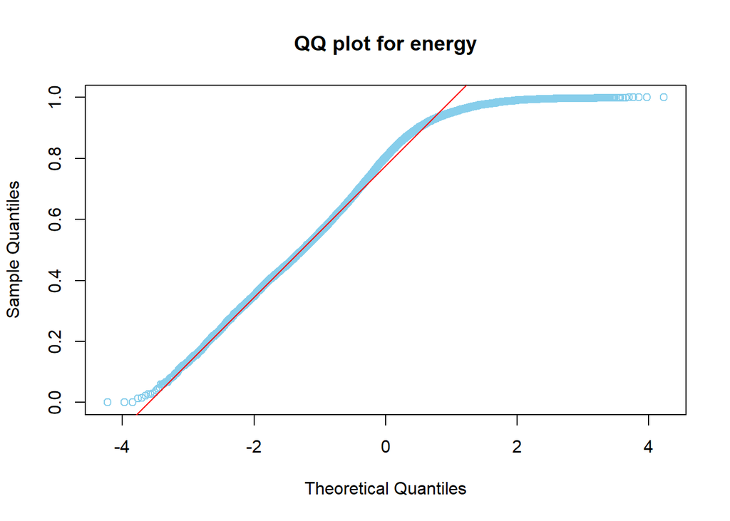

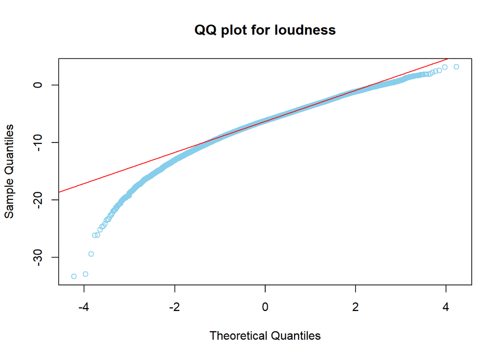

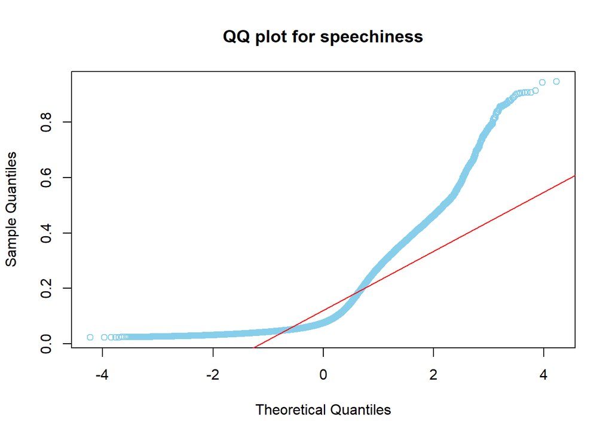

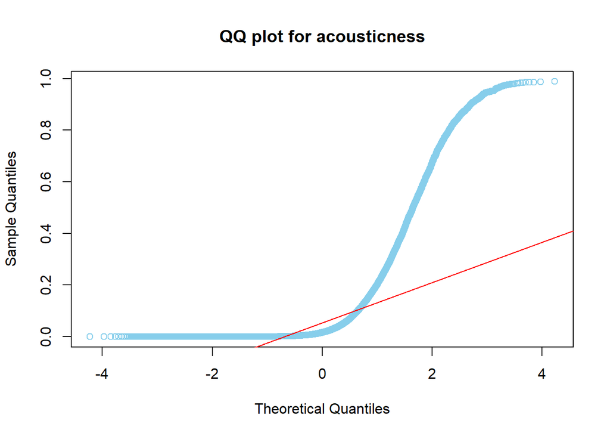

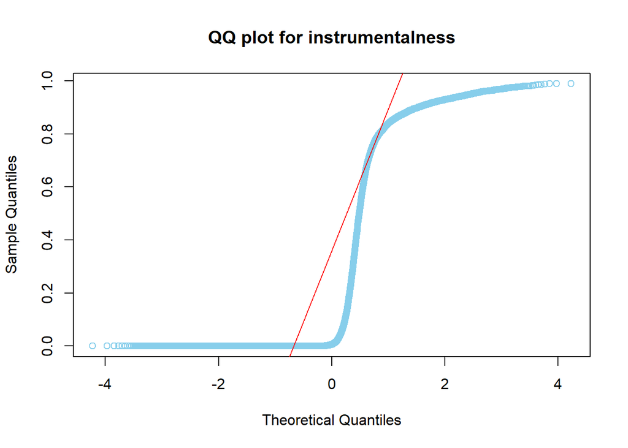

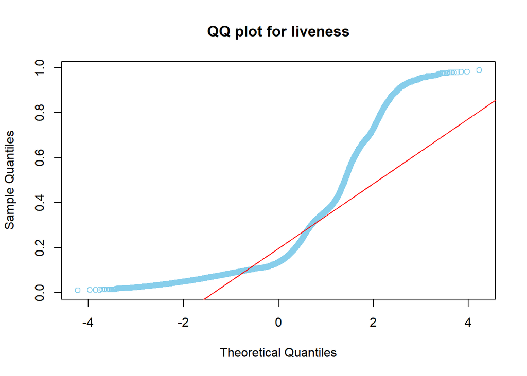

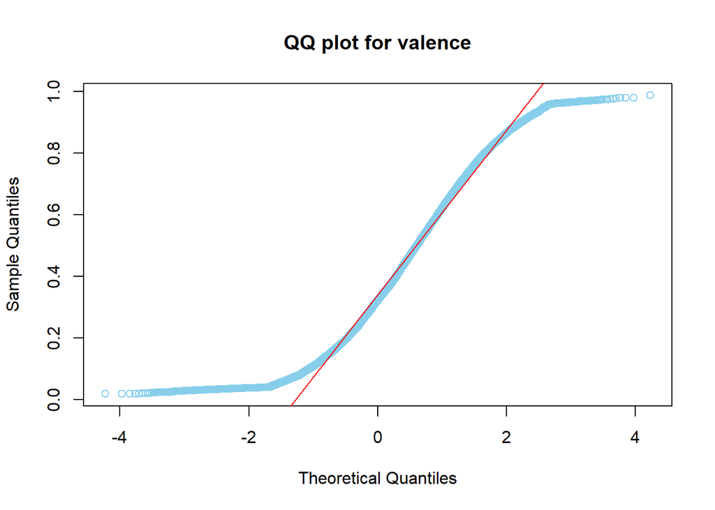

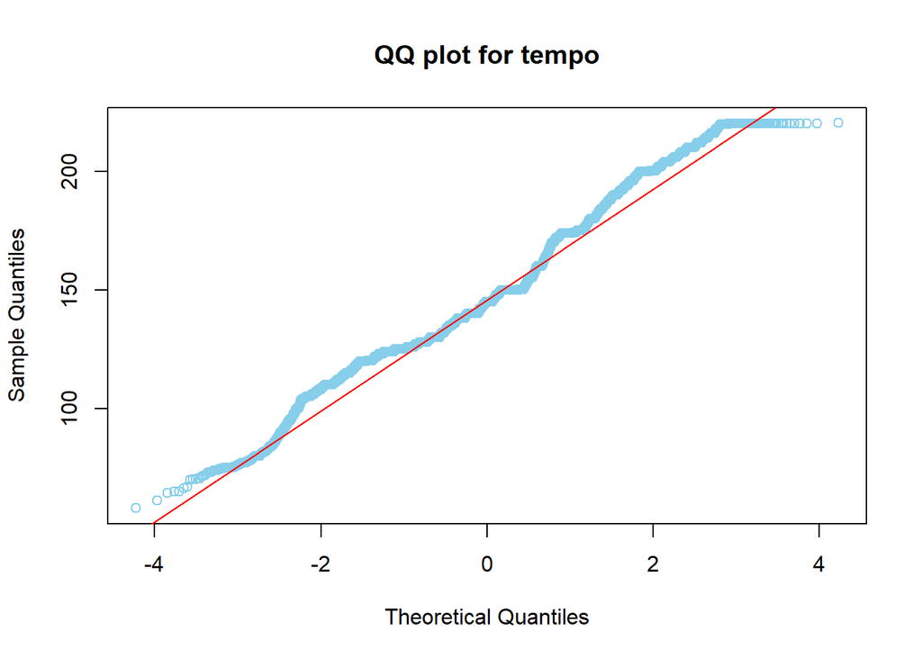

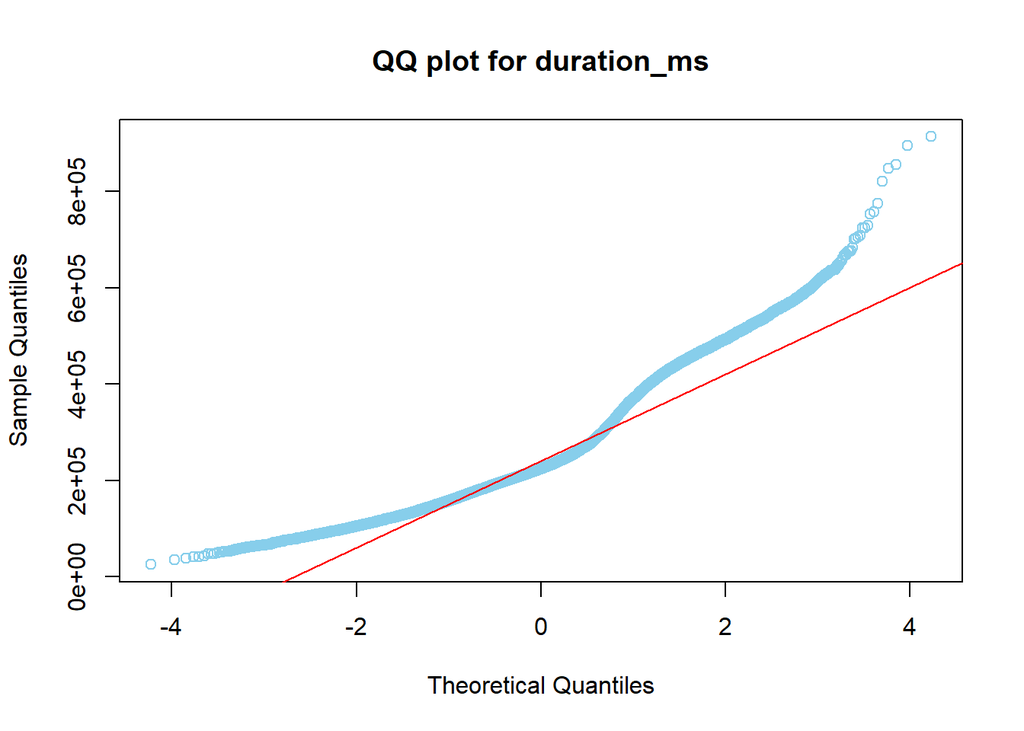

```r
# Calculate the total height for all the plots
total_height <- 4 * length(continuous_vars)

# Set the overall plotting window size
options(repr.plot.width=10, repr.plot.height=total_height)

for (column in continuous_vars) {
  qqnorm(dataset_na[[column]], main = paste("QQ plot for", column), col="skyblue")
  qqline(dataset_na[[column]], col="red")
}
```

Some Observations from QQ-plots are as follows-

*Energy*-The QQ plot for energy reveals noticeable deviations from the expected line of normality. These deviations suggest that there might be some skewness in the distribution. Visually, this hints at the data not following a perfect normal distribution.

*Speechiness*- For speechiness, the QQ plot indicates that the upper quantiles notably veer away from the expected line of normality. This visual observation suggests potential right-skewed characteristics, hinting at a distribution that might not be perfectly normal.

*Acousticness*-Acousticness, as visualized in the QQ plot, shows significant deviations from the expected line, especially in the upper tail region. This indicates a potential right-skewed distribution, suggesting the presence of outliers or extreme data points in the dataset.

*Lnstrumentalness*-The QQ plot for instrumentalness reveals that data points, especially in the upper quantiles, deviate from the expected line representing normality. This deviation hints at a distribution that might be right-skewed and not perfectly normal.

*Tempo*-The QQ plot for tempo distinctly indicates deviations, especially in the central regions of the plot. Based on this visual inspection, the distribution of tempo might have characteristics that deviate from perfect normality.

*Conclusion:* After conducting the Kolmogorov-Smirnov tests, the subsequent QQ plot analysis for various music track attributes provides deeper insights. Notably, attributes like danceability, energy, and loudness distinctly deviate from expected normal distributions. These visual indicators, combined with the KS test results, highlight non-normal behaviors, potential skewness, outliers, and unique distributional nuances. Such findings emphasize the importance of tailored data processing in subsequent analyses.

# **SMART Questions**

A SMART question is a well-defined and structured inquiry that adheres to the SMART criteria, which are specific, measurable, achievable, relevant, and time-bound. It helps to ensure that the question is clear, focused, and designed to yield actionable and meaningful results. The SMART framework is commonly used in goal-setting and project management to create objectives that are precise and attainable. When applied to formulating questions, the SMART approach helps to enhance clarity and effectiveness in seeking information or solving problems.

The investigation into various aspects of the Spotify music dataset has prompted the formulation of several SMART questions, each aimed at delving into specific attributes and relationships within the data. These questions are designed to provide focused insights into the distribution of key musical features across different genres, thereby facilitating a comprehensive understanding of the intricate nuances within the contemporary music landscape. By employing the SMART criteria—ensuring specificity, measurability, achievability, relevance, and time-bound parameters—the study aims to uncover valuable and actionable findings that contribute to the broader discourse on music analysis and genre-specific characteristics. Through these targeted inquiries, the research endeavors to shed light on the diverse musical compositions and attributes prevalent in today’s ever-evolving musical panorama, enriching the understanding of the interplay between musical elements and genre classifications.

The SMART Questions are-

1. How is the distribution of danceability across different genres?
2. What is the optimum duration_ms for tracks across different genres?
3. Is there a significant difference in the loudness of tracks between the genres Dark Trap and Underground Rap?
4. Is there an association between key (musical key of the track) and genre?
5. Is there a significant difference in energy levels across the genres Dark Trap, Underground Rap, and Emo?

Now let us analyze and try to answer the questions-

**1. How is the distribution of danceability across different genres?**

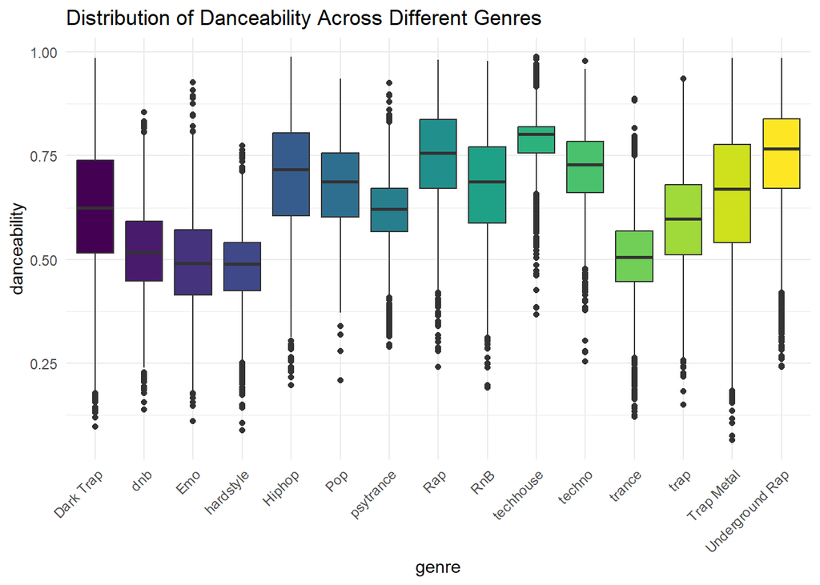

```r
theme_set(theme_minimal() + theme(axis.text.x = element_text(angle = 45, hjust = 1)))

# Plot the distribution of danceability across different genres
ggplot(data=dataset_na, aes(x=genre, y=danceability)) +
  geom_boxplot(aes(fill=genre)) +
  scale_fill_viridis_d() +
  labs(title="Distribution of Danceability Across Different Genres") +
  theme(legend.position="none")
```

On Analyzing the graph we can summarize the following about the distribution of danceability across different genres-

The analysis of the danceability levels across various genres reveals interesting insights into the rhythmic characteristics of different musical styles. Contrary to the initial assumption, the genres Dark Trap, Trap Metal, and Emo do not exhibit a notably higher median danceability compared to genres like Hiphop or Rap. Instead, their median danceability levels are moderate to lower, indicating that these genres might not primarily focus on producing tracks with highly danceable rhythms.

Genres such as Hiphop and Rap, on the other hand, demonstrate a higher median danceability when compared to Dark Trap, Trap Metal, and Emo. This finding suggests that Hiphop and Rap, as musical styles, tend to incorporate rhythmic elements that are more conducive to dancing or active movement. The higher median danceability observed in these genres highlights their emphasis on rhythmic patterns, grooves, and beats that are likely to engage listeners and encourage physical responses such as dancing or rhythmic body movements.

Overall, the analysis underscores the diverse rhythmic profiles present across different music genres, highlighting the nuanced ways in which various genres approach and prioritize danceability in their musical compositions. While genres like Hiphop and Rap focus on producing tracks with higher danceability, other genres such as Dark Trap, Trap Metal, and Emo exhibit a more moderate or lower emphasis on dance-friendly rhythms, potentially catering to different listener preferences and musical experiences.

**2. What is the optimum duration_ms for tracks across different genres?**

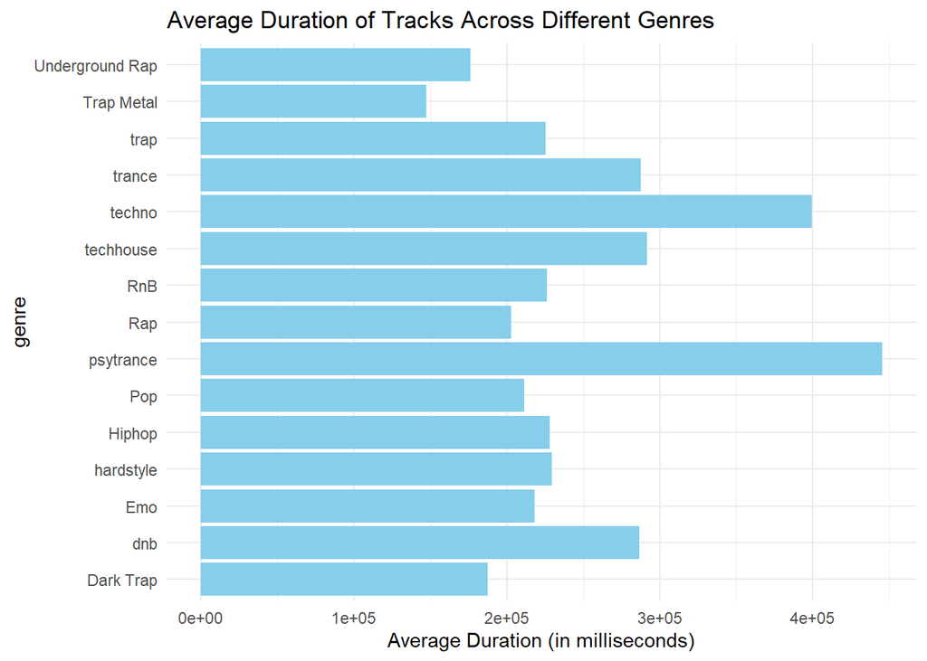

```r
# Calculate average duration for each genre
average_duration <- aggregate(duration_ms ~ genre, data=dataset_na, mean)

# Order the data by average duration
average_duration <- average_duration[order(average_duration$duration_ms), ]

# Plot the average duration
ggplot(average_duration, aes(y=genre, x=duration_ms)) +
  geom_bar(stat="identity", fill="skyblue") +
  labs(title="Average Duration of Tracks Across Different Genres",
       x="Average Duration (in milliseconds)") +
  theme_minimal()
```

The observation that most genres maintain tracks averaging between 120,000 and 240,000 milliseconds (or 2 to 4 minutes) aligns with the conventional song length preferences in the music industry. This duration range is often considered standard and widely accepted among listeners. Genres adhering to this average duration range might be catering to common preferences for song length, ensuring an optimal balance between musical expression and listener engagement.